# Bicycle Sharing

Daniel Lee

October 15th

# Set Up

### Clean up environment and load packages

```r
# clean up the RStudio environment
rm(list = ls())
# load packages: `tidyverse`, `lubridate`, `devtools` (if others are needed, load them here)
library(tidyverse)
library(lubridate)
library(devtools)
library(mosaic)
library(leaflet)
```

### Load the data

The code chunk below loads the data for you, but you should study each line to understand what it’s doing.

```r
### Load the station data set into our RStudio environment as described in the text
Stations <- mosaic::read.file("http://tiny.cc/dcf/DC-Stations.csv")
```

```
Reading data with read.csv()
```

```r
### Load the station data set into our RStudio environment as described in the text
# data_site <- "http://tiny.cc/dcf/2014-Q4-Trips-History-Data.rds"          # full data with 600k rows (uncomment to use)
data_site <- "http://tiny.cc/dcf/2014-Q4-Trips-History-Data-Small.rds"    # small data with 10k rows
Trips <- readRDS(gzcon(url(data_site)))
### Backup code if you need to download the .rds file from the web and load a local version
# Trips <- readRDS("2014-Q4-Trips-History-Data-Small.rds")
# Trips <- readRDS("2014-Q4-Trips-History-Data.rds")
```

### Always inspect the data tables when you load them

```r
str(Trips)
```

```
'data.frame':   10000 obs. of  7 variables:
 $ duration: chr  "0h 9m 15s" "0h 47m 21s" "2h 46m 22s" "0h 15m 15s" ...
 $ sdate   : POSIXct, format: "2014-11-06 16:26:00" "2014-10-12 11:30:00" "2014-12-27 14:24:00" ...
 $ sstation: chr  "15th & L St NW" "3rd & D St SE" "10th & E St NW" "4th & M St SW" ...
 $ edate   : POSIXct, format: "2014-11-06 16:35:00" "2014-10-12 12:17:00" "2014-12-27 17:10:00" ...
 $ estation: chr  "15th & L St NW" "Jefferson Dr & 14th St SW" "10th & E St NW" "5th & K St NW" ...
 $ bikeno  : chr  "W00169" "W01482" "W21346" "W00647" ...
 $ client  : chr  "Registered" "Registered" "Casual" "Casual" ...
```

### Plot check-out times. (reproduce Fig A.15)

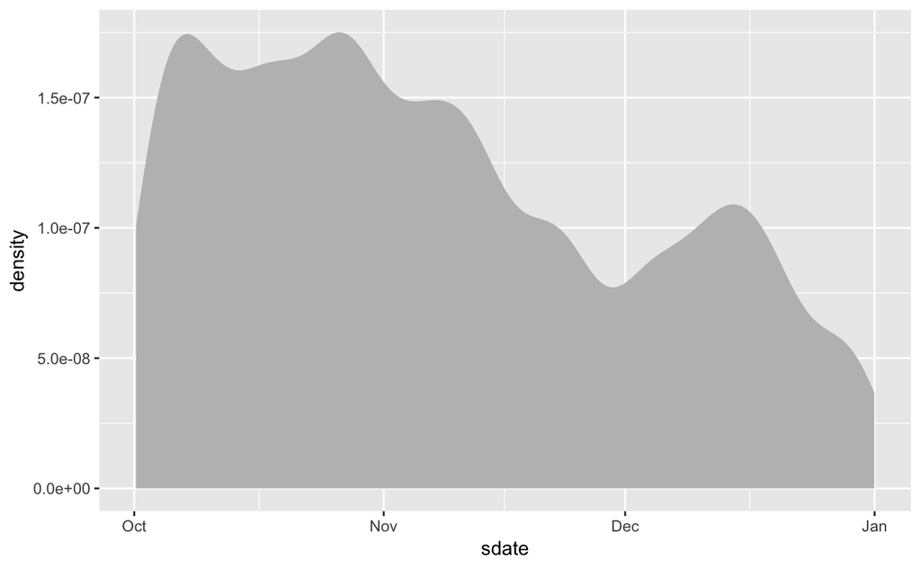

```r
Trips %>%
  ggplot(aes(x=sdate)) +
  geom_density(fill="gray", color=NA)
```

# A.1 How Long?

```r
Trips <-
  Trips %>%
  mutate(durMin = as.numeric(edate - sdate)/60)  # trip duration in minutes
# inspect data table; discern units of "durMinutes"
head(Trips)
```

|  | duration | sdate | sstation | edate | estation | bikeno | client | durMin |
| --- | --- | --- | --- | --- | --- | --- | --- | --- |
| 1 | 0h 9m 15s | 2014-11-06 16:26:00 | 15th & L St NW | 2014-11-06 16:35:00 | 15th & L St NW | W00169 | Registered | 9 |
| 2 | 0h 47m 21s | 2014-10-12 11:30:00 | 3rd & D St SE | 2014-10-12 12:17:00 | Jefferson Dr & 14th St SW | W01482 | Registered | 47 |
| 3 | 2h 46m 22s | 2014-12-27 14:24:00 | 10th & E St NW | 2014-12-27 17:10:00 | 10th & E St NW | W21346 | Casual | 166 |
| 4 | 0h 15m 15s | 2014-11-23 16:42:00 | 4th & M St SW | 2014-11-23 16:57:00 | 5th & K St NW | W00647 | Casual | 15 |
| 5 | 0h 18m 33s | 2014-11-24 17:29:00 | 1st & Washington Hospital Center NW | 2014-11-24 17:47:00 | Columbus Circle / Union Station | W21580 | Registered | 18 |
| 6 | 0h 2m 36s | 2014-12-15 13:11:00 | 11th & Kenyon St NW | 2014-12-15 13:14:00 | Park Rd & Holmead Pl NW | W21286 | Registered | 3 |

Make box & whisker plot showing the distribution of rental duration by client type. As instructed in the text, make sure you either configure your scale or use a filter to suppress outliers from dictating the axis range.

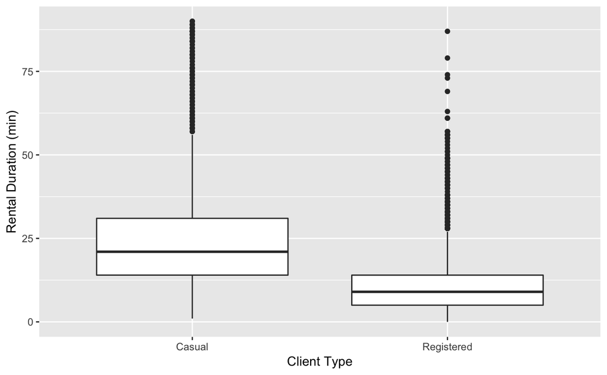

```r
Trips %>%
  ggplot(aes(x = client, y = durMin)) +
  geom_boxplot() +
  ylim(0, 90) +           # restrict plot to 90 minutes or less
  ylab("Rental Duration (min)") +
  xlab("Client Type")
```

There are many outliers for registered clients compare to casual clients.

# A.2 When are bikes used?

Note: You’ll use several functions that begin with `lubridate::` this means that those functions have come from the `lubridate` R package, which makes it easy to work with dates in R. The activity template instructed you to load this package already, but you should use Google or the RStudio help to get a sense of the kind of things this package is designed to do.

```r
Trips <-
  Trips %>%
  mutate(dayOfYear = lubridate::yday(sdate),
         dayOfWeek = lubridate::wday(sdate),
         dayOfWeekLabel = lubridate::wday(sdate, label = TRUE),
         hourOfDay = lubridate::hour(sdate),
         minuteOfHour = lubridate::minute(sdate))
```

##### Day of the year (1 to 365)

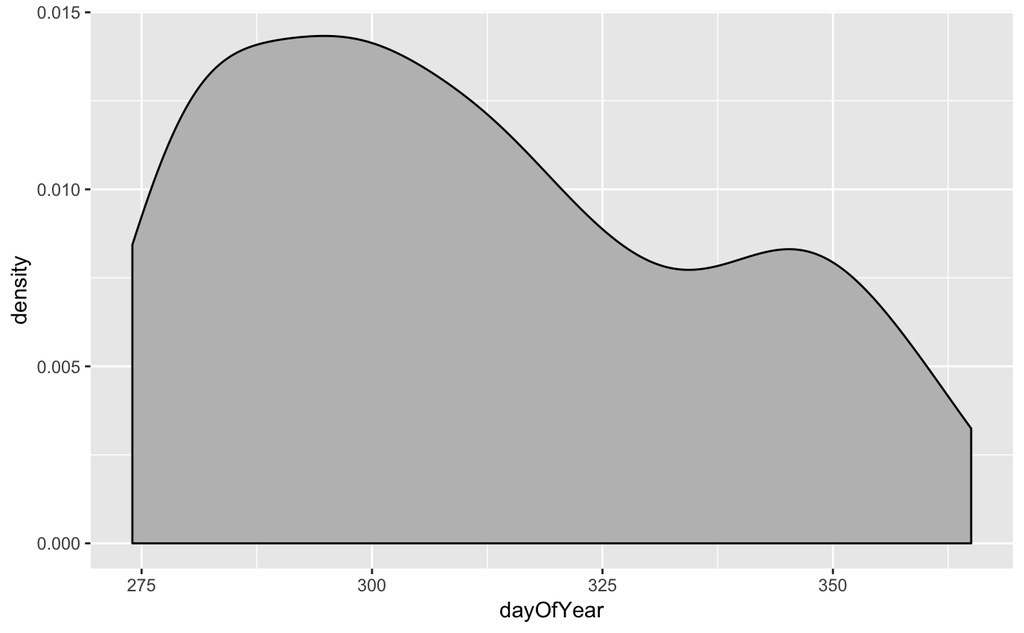

```r
Trips %>%
  ggplot(aes(x = dayOfYear)) +
  geom_density(fill = "gray", adjust = 2)
```

The graph shows a trend of negative slope which means that as day of the year increases, the number of bike use decreases.

##### Day of the week (Sunday to Saturday)

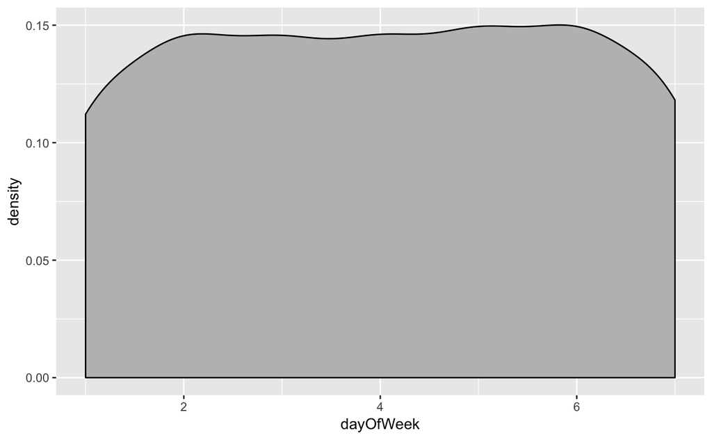

```r
Trips %>%
  ggplot(aes(x = dayOfWeek)) +
  geom_density(fill = "gray", adjust = 2)
```

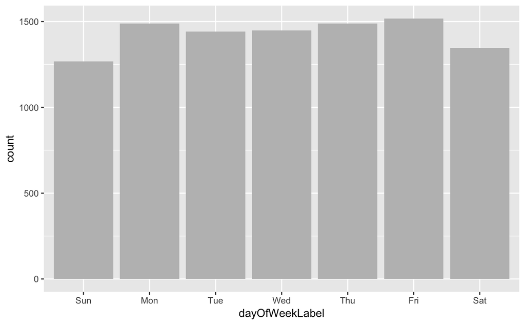

```r
Trips %>%
  ggplot(aes(x = dayOfWeekLabel)) +
  geom_bar(fill = "gray")
```

##### Hour of the day (0 to 24)

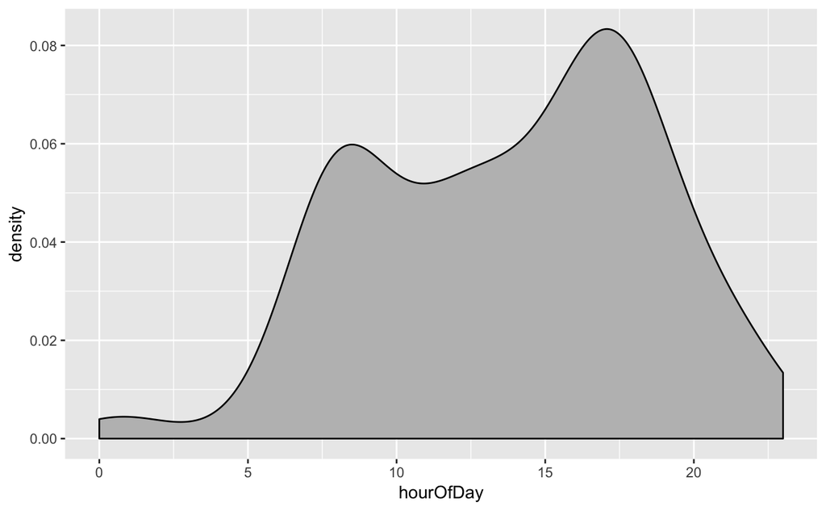

```r
Trips %>%
  ggplot(aes(x = hourOfDay)) +
  geom_density(fill = "gray", adjust = 2)
```

```r
NA
```

##### Minute in the hour (0 to 60)

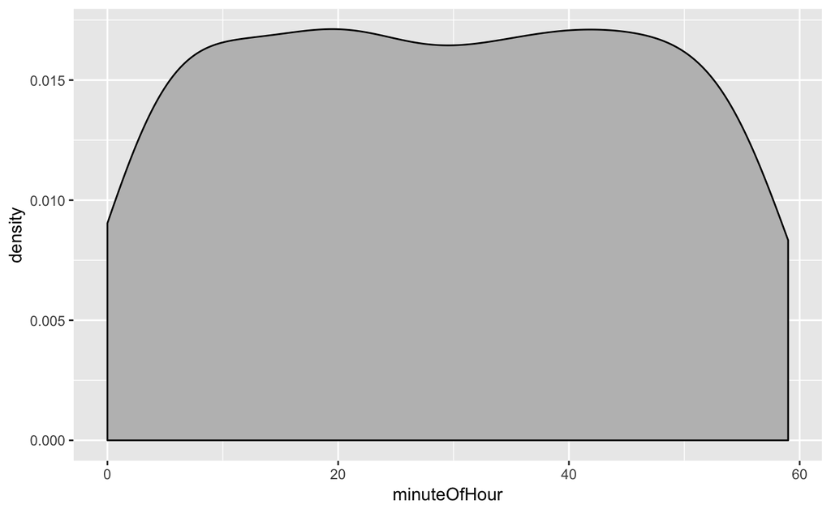

```r
Trips %>%
  ggplot(aes(x = minuteOfHour)) +
  geom_density(fill = "gray", adjust = 2)
```

### Group the bike rentals by hour, weekday, & client type

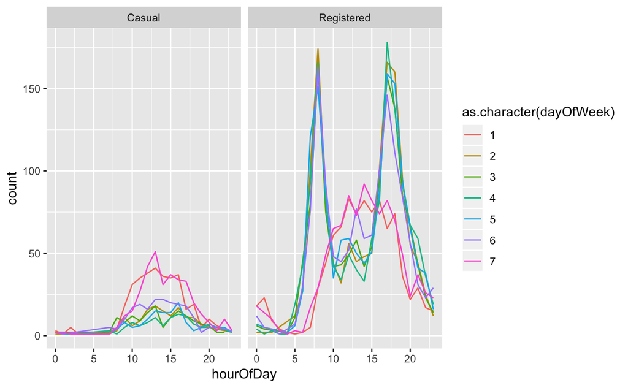

```r
Trips %>%
  group_by(client, dayOfWeek, hourOfDay) %>%
  summarise(count = n()) %>%
  ggplot(aes(x = hourOfDay, y = count)) +
  geom_line(aes(group = dayOfWeek, color = as.character(dayOfWeek))) +
  facet_wrap( ~ client)
```

### Construct a similar plot using density rather than frequency

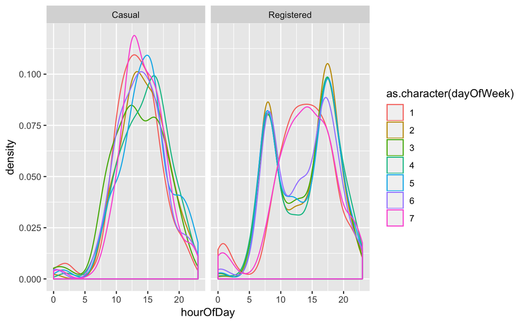

```r
Trips %>%
  ggplot(aes(x = hourOfDay)) +
  geom_density(aes(group = dayOfWeek, color = as.character(dayOfWeek))) +
  facet_wrap( ~ client)
```

The density for the casual clients are more compacted in the duration of 10-15 hours while for registered clients, they are more compact in the interval of 7-8 hours and 17-18 hours.

# A.3 How Far?

We want to calculate the distance between stations using the `haversine()` function. The `source()` function actually runs an R script found at some URL. Use a web browser to visit this URL and read about the function (it’s only a few lines).

```r
source("http://tiny.cc/dcf/haversine.R")
head(Stations)
```

|  | name | lat | long | nbBikes | nbEmptyDocks |
| --- | --- | --- | --- | --- | --- |
| 1 | 20th & Bell St | 38.85610 | -77.05120 | 7 | 4 |
| 2 | 18th & Eads St. | 38.85725 | -77.05332 | 8 | 3 |
| 3 | 20th & Crystal Dr | 38.85640 | -77.04920 | 8 | 7 |
| 4 | 15th & Crystal Dr | 38.86017 | -77.04959 | 9 | 2 |
| 5 | Aurora Hills Community Ctr/18th & Hayes St | 38.85787 | -77.05949 | 7 | 4 |
| 6 | Pentagon City Metro / 12th & S Hayes St | 38.86230 | -77.05994 | 7 | 12 |

Caution: At some point, the book remarks that “one end of Washington DC to the other is about 14.1 miles.” It turns out this seems to be a misleading hint. When you reach that part of the activity, find the two stations in the data that are farthest apart and investigate their locations to make sure they are legitimate. You’ll probably need to explore a map of the Washington DC area on the Internet to figure things out.

```r
# create a working copy of the data & rename to identify starting Station
Simple <-
  Stations %>%
  rename(sstation = name)
# create another copy and rename variables for use as the ending station
Simple2 <-
  Simple %>%
  rename(estation = sstation, lat2 = lat, long2 = long)
# inspect Simple & Simple2
head(Simple)
```

|  | sstation | lat | long | nbBikes | nbEmptyDocks |
| --- | --- | --- | --- | --- | --- |
| 1 | 20th & Bell St | 38.85610 | -77.05120 | 7 | 4 |
| 2 | 18th & Eads St. | 38.85725 | -77.05332 | 8 | 3 |
| 3 | 20th & Crystal Dr | 38.85640 | -77.04920 | 8 | 7 |
| 4 | 15th & Crystal Dr | 38.86017 | -77.04959 | 9 | 2 |
| 5 | Aurora Hills Community Ctr/18th & Hayes St | 38.85787 | -77.05949 | 7 | 4 |
| 6 | Pentagon City Metro / 12th & S Hayes St | 38.86230 | -77.05994 | 7 | 12 |

```r
head(Simple2)
```

|  | estation | lat2 | long2 | nbBikes | nbEmptyDocks |
| --- | --- | --- | --- | --- | --- |
| 1 | 20th & Bell St | 38.85610 | -77.05120 | 7 | 4 |
| 2 | 18th & Eads St. | 38.85725 | -77.05332 | 8 | 3 |
| 3 | 20th & Crystal Dr | 38.85640 | -77.04920 | 8 | 7 |
| 4 | 15th & Crystal Dr | 38.86017 | -77.04959 | 9 | 2 |
| 5 | Aurora Hills Community Ctr/18th & Hayes St | 38.85787 | -77.05949 | 7 | 4 |
| 6 | Pentagon City Metro / 12th & S Hayes St | 38.86230 | -77.05994 | 7 | 12 |

```r
# join the starting and ending data tables together
StationPairs <-
  merge(Simple, Simple2, by = NULL)
# inspect station pairs data table
head(StationPairs)
```

|  | sstation | lat | long | nbBikes.x | nbEmptyDocks.x | estation | lat2 | long2 | nbBikes.y | nbEmptyDocks.y |
| --- | --- | --- | --- | --- | --- | --- | --- | --- | --- | --- |
| 1 | 20th & Bell St | 38.85610 | -77.05120 | 7 | 4 | 20th & Bell St | 38.8561 | -77.0512 | 7 | 4 |
| 2 | 18th & Eads St. | 38.85725 | -77.05332 | 8 | 3 | 20th & Bell St | 38.8561 | -77.0512 | 7 | 4 |
| 3 | 20th & Crystal Dr | 38.85640 | -77.04920 | 8 | 7 | 20th & Bell St | 38.8561 | -77.0512 | 7 | 4 |
| 4 | 15th & Crystal Dr | 38.86017 | -77.04959 | 9 | 2 | 20th & Bell St | 38.8561 | -77.0512 | 7 | 4 |
| 5 | Aurora Hills Community Ctr/18th & Hayes St | 38.85787 | -77.05949 | 7 | 4 | 20th & Bell St | 38.8561 | -77.0512 | 7 | 4 |
| 6 | Pentagon City Metro / 12th & S Hayes St | 38.86230 | -77.05994 | 7 | 12 | 20th & Bell St | 38.8561 | -77.0512 | 7 | 4 |

```r
# compute distances with haversine()
PairDistances <-
  StationPairs %>%
  transmute(sstation, estation, distance = haversine(lat, long, lat2, long2)) %>%
  select(sstation, estation, distance)
# inspect PairDistances
head(PairDistances)
```

|  | sstation | estation | distance |
| --- | --- | --- | --- |
| 1 | 20th & Bell St | 20th & Bell St | 0.0000000 |
| 2 | 18th & Eads St. | 20th & Bell St | 0.2237177 |
| 3 | 20th & Crystal Dr | 20th & Bell St | 0.1763635 |
| 4 | 15th & Crystal Dr | 20th & Bell St | 0.4734716 |
| 5 | Aurora Hills Community Ctr/18th & Hayes St | 20th & Bell St | 0.7441989 |
| 6 | Pentagon City Metro / 12th & S Hayes St | 20th & Bell St | 1.0236764 |

Graph

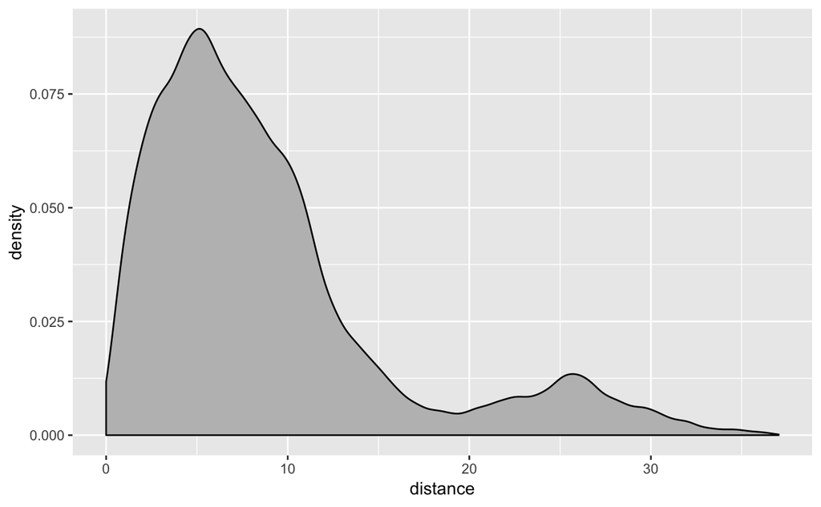

```r
PairDistances %>%
  ggplot(aes(x = distance)) +
  geom_density(fill = "gray")
```

```r
PairDistances %>%
  arrange(desc(distance)) %>%
  head()
```

|  | sstation | estation | distance |
| --- | --- | --- | --- |
| 1 | Needwood Rd & Eagles Head Ct | Prince St & Union St | 37.03506 |
| 2 | Prince St & Union St | Needwood Rd & Eagles Head Ct | 37.03506 |
| 3 | Shady Grove Metro West | Prince St & Union St | 36.84887 |
| 4 | Prince St & Union St | Shady Grove Metro West | 36.84887 |
| 5 | Needwood Rd & Eagles Head Ct | Market Square / King St & Royal St | 36.79420 |
| 6 | Market Square / King St & Royal St | Needwood Rd & Eagles Head Ct | 36.79420 |

Joining PariDistances table with Trips

```r
RideDistances <-
  Trips %>%
  inner_join(PairDistances, by = c("sstation", "estation"))
```

Graph

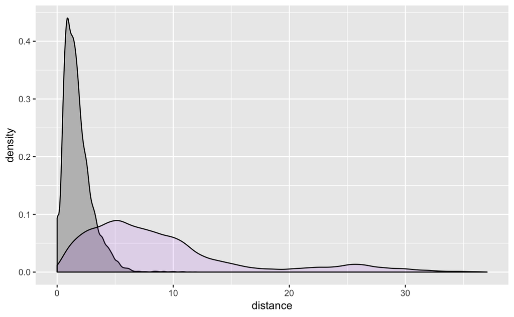

```r
RideDistances %>%
  ggplot(aes(x = distance)) +
  geom_density(fill = "gray") +
  geom_density(data = PairDistances, aes(x = distance), fill = "purple", alpha = 0.1)
```

# A.4 Mapping the Stations

```r
library(leaflet)
stationMap <-
  leaflet(Stations) %>%
  addTiles() %>%
  addCircleMarkers(radius=2, color="red") %>%
  setView(-77.04, 38.9, zoom=12)
```

```
Assuming "long" and "lat" are longitude and latitude, respectively
```

```r
stationMap
```

[interactive chart not shown]

# A.5 Long-distance stations (Extra Credit)

```r
library(leaflet)
stationMap <-
  leaflet(Stations) %>%
  addTiles() %>%
  addCircleMarkers(radius=1, color="red") %>%
  addCircles(radius = ~ mid, color="blue", opacity = 0.001) %>%
  setView(-77.04, 38.9, zoom=12)
```

```
Assuming "long" and "lat" are longitude and latitude, respectively
Assuming "long" and "lat" are longitude and latitude, respectively
```

```r
stationMap
```

[interactive chart not shown]